# The t-test and hypothesis testing, MiCM Fall 2022 Workshop

### t-test exercises

As an exercise, extract the t-statistic and p-value you calculated above using `$`

```r
#t_test_results$
```

Now, try the t-test we did above, but try making the sample size much larger (say, n=1000 or n=10000). Do you notice a difference in the result of a t-test?

```r
#set.seed(20221011) # Seed for reproducibility
#n <-  # Sample size (CHANGE THIS)

#mu1 <- 0 # Mean of sample 1
#mu2 <- 0.1 # Mean of sample 2

#sd1 <- 1 # Standard deviation 1
#sd2 <- 1 # Standard deviation 2

#ve <- sd1 == sd2

# Generate two samples of of size n of normally-distributed data.
# Sample x1 has a mean of mu1 and standard deviation sd1
# Sample x2 has a mean of mu2 and standard deviation sd2
#x1 <- rnorm(n, mu1, sd1)
#x2 <- rnorm(n, mu2, sd2)

#t.test(x1,x2,var.equal = ve)
```

Try the t-test again. Make the sample size smaller (say, n=20) but change the means

```r
#set.seed(20221011) # Seed for reproducibility
#n <- 20 # Sample size

#mu1 <-  # Mean of sample 1 (CHANGE THIS)
#mu2 <-  # Mean of sample 2 (CHANGE THIS)

#sd1 <- 1 # Standard deviation 1
#sd2 <- 1 # Standard deviation 2

#ve <- sd1 == sd2

# Generate two samples of of size n of normally-distributed data.
# Sample x1 has a mean of mu1 and standard deviation sd1
# Sample x2 has a mean of mu2 and standard deviation sd2
#x1 <- rnorm(n, mu1, sd1)
#x2 <- rnorm(n, mu2, sd2)

#t.test(x1, x2, var.equal = ve)
```

### ANOVA and the F-test

What if the data have more than two groups? This leads naturally into Analysis of Variance (ANOVA).

We will create three “populations” with a measurement between them. These three groups will have different means to ensure that they give a statistically significant result.

```r
set.seed(20221011)

# Our artificial data will have three different means
m1 <- rnorm(30, mean = 25, sd = 5)
m2 <- rnorm(30, mean = 30, sd = 6)
m3 <- rnorm(30, mean = 22, sd = 7)

ms <- c(m1, m2, m3) # Combine our three measures into one vector

# Our vector of group labels A, B, and C
ls <- as.factor(c(rep("A",30),rep("B",30),rep("C",30)))

# Make it into a data frame
df_anova <- data.frame(ms, ls)
colnames(df_anova) <- c("measure","group")
```

First, we should visualize our data. We can use a boxplot to compare all the populations against each other.

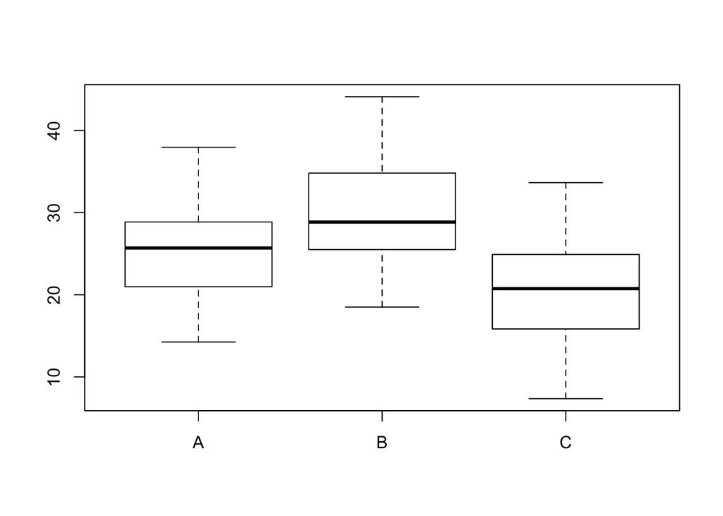

```r
boxplot(measure ~ group, data = df_anova)
```

These groups certainly look different, but we should run an ANOVA just in case. We’ll use the `aov` command. The command takes the formula `y ~ x` as an input, where `y` is the variable we are measuring and `x` is the grouping.

```r
# Run the ANOVA
results_aov <- aov(measure ~ group, data = df_anova)

# Call the results of the ANOVA
print("---Printing results of ANOVA---")
```

```
## [1] "---Printing results of ANOVA---"
```

```r
results_aov
```

```
## Call:
##    aov(formula = measure ~ group, data = df_anova)
##
## Terms:
##                    group Residuals
## Sum of Squares  1332.216  3485.576
## Deg. of Freedom        2        87
##
## Residual standard error: 6.32962
## Estimated effects may be unbalanced
```

```r
# Print the summary
print("---Printing summary---")
```

```
## [1] "---Printing summary---"
```

```r
summary(results_aov)
```

```
##             Df Sum Sq Mean Sq F value   Pr(>F)
## group        2   1332   666.1   16.63 7.67e-07 ***
## Residuals   87   3486    40.1
## ---
## Signif. codes:  0 '***' 0.001 '**' 0.01 '*' 0.05 '.' 0.1 ' ' 1
```

We now have a significant result. What else can we say? Let’s use `$` to examine the ANOVA object:

```r
results_aov$coefficients
```

```
## (Intercept)      groupB      groupC
##   25.382285    4.521143   -4.900450
```

These coefficients show us what our results are relative to Group A.

We can also use `plot` to see what our residuals look like.

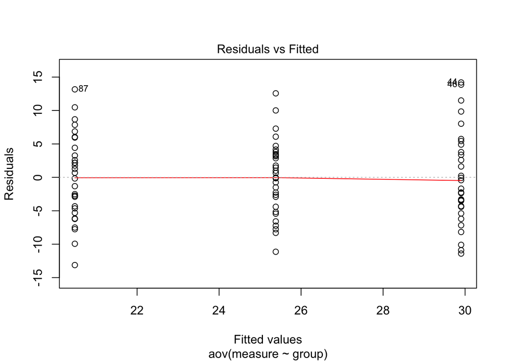

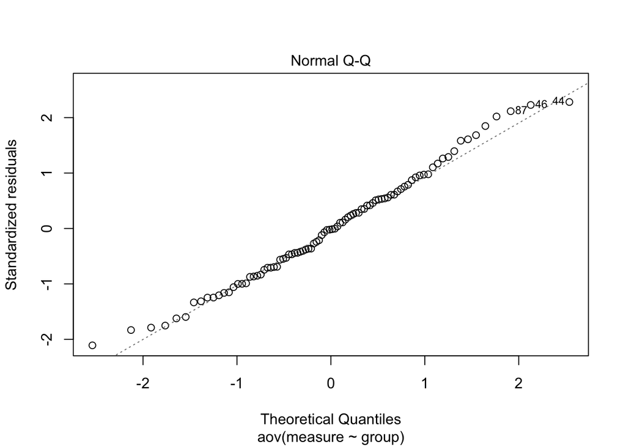

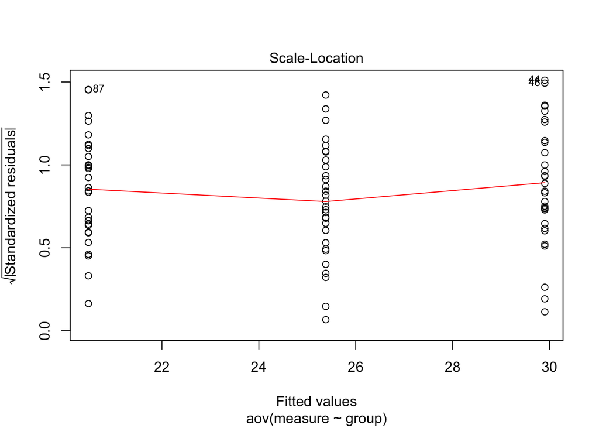

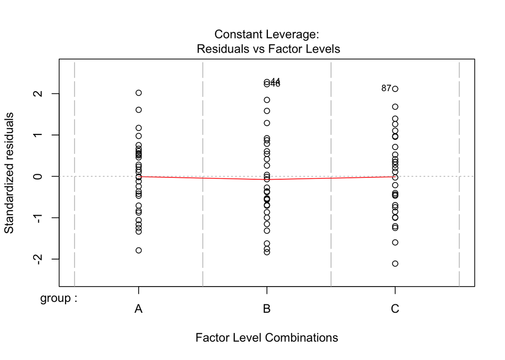

[output not shown]

```r
plot(results_aov)
```

### ANOVA exercises

Load the base R data `PlantGroup` using the command `data("PlantGrowth")`. Visualize the groups using a boxplot and run an ANOVA on them. Extract the coefficients using `$`.

```r
data("PlantGrowth") # Load the data (it may take a second)
```

Run the `TukeyHSD()` command on the ANOVA you just created. Where are the differences in the model?

```r
# TukeyHSD(...)
```

For two- and three-way ANOVA models, there are good examples at: https://www.datanovia.com/en/lessons/anova-in-r/. They require the `datarium` package.